# FLUXNET-CH4 Upscaling

Gavin McNicol

2/22/2021

Load packages and ggplot theme:

```r
library(tidyverse)
library(lubridate)
library(raster)
library(oce) # for time series transformations
source("code/ggplot_theme.R")
```

**NOTE: This work flow uses many large files so most data is stored locally and requires hard filepaths** The local file path used for all large files is: `/Volumes/LACIE SHARE/Stanford CH4/upch4_local/`.

Set the local head directory:

```r
loc <- "/Volumes/LACIE SHARE/Stanford CH4/upch4_local/"
```

#### Workflow

1. Objective of Study
2. Input Data
   - FLUXNET-CH4 Data
   - Gridded Data
3. FLUXNET-CH4 Pre-Processing
   - FLUXNET-CH4 Data Preparation
     - Averaging
     - Variable Selection
4. Gridded Data Pre-Processing
   - Grid Preparation
     - Potential Radiation (computed)
     - MODIS
   - Grid Extraction
     - Canopy Height
     - Computed (Rpot)
     - Compound Topographic Index
     - Earth Environment
     - N and S Deposition
     - SoilGrids
     - TerraClimate
     - Fractional Vegetation Cover (VCF)
     - Wetland Extent (WAD2M)
     - WorldClim 2.0
   - Merge Gridded Data
   - Gridded Data Quality Control
5. Finalize Training Data
   - Subset Wetlands, Dates
   - Cluster Sites for Cross Validation
   - Finalize Data
     - Remove Extraneous
     - Impute Missing Data
     - Add Lagged Data
   - FLUXNET-CH4 Data Quality Control
   - Table of Final FLUXNET-CH4 Inputs
6. Forward Feature Selection (FFS)
   - Filter Weekly Data
   - Feature Subset Experiments
   - FFS
     - First Pair
     - Additional Stepwise Features
     - FFS Evolution Plots
   - Summarize FFS Performance
7. Cross Validation
   - ML Model Training
     - RF and Final Predictors or Subsets
     - XGB and Final Predictors or Subsets
     - ANN and Final Predictors or Subsets
     - RNN and Final Predictors or Subsets
   - Output Ensembles and Predictions
   - Validation
     - Global Performance
     - Site-means
     - Monthly Seasonal Cycles
     - Monthly Anomalies
8. Variable Importances
   - Variable Importance Rankings
   - Variable Responses
   - Partial Dependency Plots
   - ShapR
9. Upscaled Model with Monte Carlo (MC)
   - Forcing Data
     - Mapping
     - Member Product Choices
     - Evaluate Product Divergence
   - Data Preparation
     - Extract Gridded Data for MC
     - Pre-Process FLUXNET-CH4 for MC
   - MC Simulations
   - MC ML Model Training
   - MC ML Model Validation
10. Upscaling
    - Prepare Member Forcing Data
    - Run on Computing Cluster
      - Output Grids and Sums
    - Product Evaluation
      - Unweighted Wetland Fluxes (nmol)
      - Weighted Sums and Uncertainties (Tg)
      - Independent Validation
11. Data Representativeness
    - Prepare Gridded Data
    - Global Dissimilarity
    - Tower Constituency
    - Extrapolation Errors
      - MC ML Model Training - Dissimilarity Only

[**Link to Workflow Figure**](https://drive.google.com/drive/folders/1jiFyqzoxxMpdtRLCwxCtzKpfILRNIW5K)

$~$

#### 1. Objective of Study

The goal of `FLUXNET-CH4 Upscaling` is to implement FLUXCOM-like ML approaches (e.g. Jung et al. 2020) to train a machine learning model using eddy covariance data that can predict wetland methane (CH4) fluxes globally. The predictions should be readily comparable to the Global Carbon Project (GCP) bottom-up process model ensembles that inform the Global Methane Budget (Saunois et al. 2020). Wetland fluxes specifically, rather than methane fluxes from all terrestrial ecosystems, are the predictive goal of this study because 1) most eddy covariance data available are in wetlands, with limited coverage across the multitude of upland ecosystems, 2) methane fluxes are highest and most variable in wetlands, and 3) comparable bottom-up process models predict wetland fluxes, then scale predictions to a global grid-cell using a prescribed (diagnostic runs) or model-derived (prognostic runs) wetland extent. In the last GCP Global Methane Budget (Saunois et al. 2020), diagnostic runs used the WAD2M product (Zhang et al. in review). WAD2M includes coastal wetlands, however, we exclude coastal wetlands from the upscaling because they are salt-influenced and we do not have consistent salinity coverage, thus their inclusion is likely to bias flux estimates low even in non-coastal wetlands. The final model will be forced with available globally gridded data. Final product specifications are:

- Monthly time-step
- Historic reconstruction: ca. 2000 - 2018
- 0.25-degree grid cell resolution (as is WAD2M)
- Propagates training data uncertainties using Monte Carlo simulations
- Considers sensitivity to global forcing data product choices

$~$

#### 2. Input Data

**FLUXNET-CH4 Data**

The eddy covariance data used in this study are publicly available as part of the FLUXNET-CH4 community product V1.0 at [fluxnet.org](https://fluxnet.org/data/fluxnet-ch4-community-product/). The FLUXNET-CH4 synthesis activity is introduced in Knox et al. 2019 along with a detailed description of the eddy covariance post-processing steps including methane flux (FCH4) uncertainties. The first full (V1.0) dataset release (FLUXNET-CH4, hereafter) is described for 81 sites and is used in a wetland seasonality analysis in Delwiche et al. in review. **Data for this CH4 Upscaling Project were downloaded from fluxnet.org on Feb 22, 2021. [Download Manifest](https://docs.google.com/spreadsheets/d/1--_-XyBqsyiMIdc6JXqhilOOYFLeaY-UTMFhhI4Sd5M/edit#gid=0)**

Links:

- [FLUXNET-CH4 Site (81) Metadata](https://docs.google.com/spreadsheets/d/1DN0huLs-vVM3g_XcF1hBQrTpkKaGhzuWwaacfbe4iCo/edit#gid=1384338468)
- Permission was received via email on Feb 22, 2021, to use *Tier 2 Data Policy* sites in this study (SE-St1 and RU-Vrk; PI Thomas Friborg)
- FLUXNET-CH4 data were used both for methane fluxes (FCH4; target variable) and tower-measured bio-meteorological variables (e.g., LE, GPP, TA; predictors)
  - Link to [FLUXNET.org variable descriptions](https://fluxnet.org/data/fluxnet-ch4-community-product/data-variables/)

$~$

**Gridded Data (Predictors)**

A summary of predictors (`Predictor Summary`) is available [here](https://docs.google.com/spreadsheets/d/1DN0huLs-vVM3g_XcF1hBQrTpkKaGhzuWwaacfbe4iCo/edit#gid=0), as well as an appendix table with all individual predictors (`Appendix: All Predictors`). Candidate predictors were drawn from a mix of source classes (EC tower measurements, global models, computations from observed data, or remote sensing (e.g. NASA MODIS)), different information content groups (Spatial-only or Spatio-temporal), and at different temporal frequencies (Static, Yearly, Monthly, Weekly, or Half-hourly). Using this information, we assigned each candidate predictor to a class (Generic, Climate, Biometeorological, Land Cover, Soil and Relief, or Greenness) to evaluate predictive power of particular classes, given the likelihood for redundancy in useful predictors across the full predictor set. For MODIS predictors, we computed the mean seasonal cycle (`_msc`), and yearly mean, min, max, and amplitude parameters, as in Tramontana et al. (2016) and Jung et al. (2020). For derived TerraClimate soil moisture and actual evapotranspiration (aet) we computed the interannual range and annual seasonality. More information on preprocessing of predictors is provided in the manuscript.

$~$

#### 3. FLUXNET-CH4 Pre-Processing

##### Local machine steps:

- Create a copy of FLUXNET-CH4 data and name it `/fluxnet-ch4-data-original`
- Unzip all site flux files in `/fluxnet-ch4-data`
- Reorganize into half-hourly (`/hh`) and `/daily` folders for easy access

##### Look at one site of **daily means** data.

```r
# setwd(loc)
# files <- list.files("fluxnet-ch4-data/daily/")
# one_site <- read_csv(paste(loc, "fluxnet-ch4-data/daily/", files[1], sep = ""))
# head(one_site)
```

Issue: **There is also no uncertainty (`_UNC`) estimate on the downloaded daily mean data.**

##### Clean up workspace:

```r
# rm(one_site)
```

##### Look at one site of **half-hourly** data.

```r
setwd(loc)
files <- list.files("fluxnet-ch4-data/hh/")
one_site <- read_csv(paste(loc, "fluxnet-ch4-data/hh/", files[1], sep = ""))
head(one_site)
```

```
## # A tibble: 6 x 51
##   TIMESTAMP_START TIMESTAMP_END   NEE     H    LE  FCH4 USTAR   SW_IN SW_OUT
##             <dbl>         <dbl> <dbl> <dbl> <dbl> <dbl> <dbl>   <dbl>  <dbl>
## 1    201312060000  201312060030 -9999 -9999 -9999 -9999  0.09 -0.943   1.45
## 2    201312060030  201312060100 -9999 -9999 -9999 -9999  0.07 -0.817   0.978
## 3    201312060100  201312060130 -9999 -9999 -9999 -9999  0.07 -0.834   0.917
## 4    201312060130  201312060200 -9999 -9999 -9999 -9999  0.06  0.490   0.817
## 5    201312060200  201312060230 -9999 -9999 -9999 -9999  0.09 -0.0222  0.414
## 6    201312060230  201312060300 -9999 -9999 -9999 -9999  0.07  0.269   0.757
## # … with 42 more variables: LW_IN <dbl>, LW_OUT <dbl>, NETRAD <dbl>,
## #   PPFD_IN <dbl>, PPFD_OUT <dbl>, VPD <dbl>, RH <dbl>, PA <dbl>, TA <dbl>,
## #   P <dbl>, TS_1 <dbl>, TS_2 <dbl>, G <dbl>, WTD <dbl>, GPP_NT <dbl>,
## #   RECO_NT <dbl>, GPP_DT <dbl>, RECO_DT <dbl>, WD <dbl>, WS <dbl>,
## #   NEE_F <dbl>, H_F <dbl>, LE_F <dbl>, FCH4_F <dbl>, SW_IN_F <dbl>,
## #   SW_OUT_F <dbl>, LW_IN_F <dbl>, LW_OUT_F <dbl>, NETRAD_F <dbl>, VPD_F <dbl>,
## #   RH_F <dbl>, PA_F <dbl>, TA_F <dbl>, P_F <dbl>, WTD_F <dbl>, WS_F <dbl>,
## #   LE_F_ANNOPTLM <dbl>, NEE_F_ANNOPTLM <dbl>, FCH4_F_ANNOPTLM <dbl>,
## #   FCH4_F_RANDUNC <dbl>, FCH4_F_ANNOPTLM_UNC <dbl>, FCH4_F_ANNOPTLM_QC <dbl>
```

- Half-hourly data has `FCH4` uncertainty columns `FCH4_F_RANDUNC` and `FCH4_F_ANNOPTLM_UNC`. Can be averaged over day or week.
- Missing values are filled with `-9999`

##### Get FLUXNET-CH4 site names:

```r
site.names <- paste( substr(files, 5, 6), substr(files, 8, 10), sep = "")
```

##### Create a pristine replicate:

```r
hh2 <- hh
```

##### Look at all column names (including TIMESTAMP columns, to see date and time format):

```r
names(hh[[1]])
```

```
##  [1] "TIMESTAMP_START"     "TIMESTAMP_END"       "NEE"
##  [4] "H"                   "LE"                  "FCH4"
##  [7] "USTAR"               "SW_IN"               "SW_OUT"
## [10] "LW_IN"               "LW_OUT"              "NETRAD"
## [13] "PPFD_IN"             "PPFD_OUT"            "VPD"
## [16] "RH"                  "PA"                  "TA"
## [19] "P"                   "TS_1"                "TS_2"
## [22] "G"                   "WTD"                 "GPP_NT"
## [25] "RECO_NT"             "GPP_DT"              "RECO_DT"
## [28] "WD"                  "WS"                  "NEE_F"
## [31] "H_F"                 "LE_F"                "FCH4_F"
## [34] "SW_IN_F"             "SW_OUT_F"            "LW_IN_F"
## [37] "LW_OUT_F"            "NETRAD_F"            "VPD_F"
## [40] "RH_F"                "PA_F"                "TA_F"
## [43] "P_F"                 "WTD_F"               "WS_F"
## [46] "LE_F_ANNOPTLM"       "NEE_F_ANNOPTLM"      "FCH4_F_ANNOPTLM"
## [49] "FCH4_F_RANDUNC"      "FCH4_F_ANNOPTLM_UNC" "FCH4_F_ANNOPTLM_QC"
```

```r
head(hh[[1]]$TIMESTAMP_END)
```

```
## [1] 201312060030 201312060100 201312060130 201312060200 201312060230
## [6] 201312060300
```

##### Write and apply function to expand `TIMESTAMP_END` into`Year`, `Month`, `Week`, `Day`, and `DOY` variables to facilitate merging with other data:

```r
expand_date <- function(hh_data) {
  hh_data <- hh_data %>%
  mutate(Year = as.numeric(substr(TIMESTAMP_END, 1, 4)),
         Month = as.numeric(substr(TIMESTAMP_END, 5, 6)),
         Day = as.numeric(substr(TIMESTAMP_END, 7, 8)),
         Date = make_date(Year, Month, Day),
         DOY = yday(Date),
         Week = ceiling(DOY/7),
         Week = ifelse(Week == 53, 52, Week)) %>%
    group_by(Year, DOY) %>%
    mutate(HH = 1:n()) %>%
  dplyr::select(Year, Month, Week, Day, HH, DOY, everything(), - Date, -TIMESTAMP_START, -TIMESTAMP_END)
}

hh <- lapply(hh, expand_date)
hh[[2]] # check it worked
```

```
## # A tibble: 17,519 x 42
## # Groups:   Year, DOY [365]
##     Year Month  Week   Day    HH   DOY     NEE       H      LE  FCH4  USTAR
##    <dbl> <dbl> <dbl> <dbl> <int> <dbl>   <dbl>   <dbl>   <dbl> <dbl>  <dbl>
##  1  2018     1     1     1     1     1 -9999   -9999   -9999   -9999 0.0597
##  2  2018     1     1     1     2     1 -9999   -9999   -9999   -9999 0.0815
##  3  2018     1     1     1     3     1    24.6   -38.0    21.5 -9999 0.167
##  4  2018     1     1     1     4     1 -9999   -9999   -9999   -9999 0.0418
##  5  2018     1     1     1     5     1 -9999   -9999   -9999   -9999 0.0303
##  6  2018     1     1     1     6     1 -9999   -9999   -9999   -9999 0.0626
##  7  2018     1     1     1     7     1 -9999   -9999   -9999   -9999 0.104
##  8  2018     1     1     1     8     1 -9999   -9999   -9999   -9999 0.05
##  9  2018     1     1     1     9     1 -9999   -9999   -9999   -9999 0.0336
## 10  2018     1     1     1    10     1 -9999   -9999   -9999   -9999 0.0501
## # … with 17,509 more rows, and 31 more variables: SW_IN <dbl>, PPFD_IN <dbl>,
## #   VPD <dbl>, RH <dbl>, PA <dbl>, TA <dbl>, GPP_NT <dbl>, RECO_NT <dbl>,
## #   GPP_DT <dbl>, RECO_DT <dbl>, WD <dbl>, WS <dbl>, NEE_F <dbl>, H_F <dbl>,
## #   LE_F <dbl>, FCH4_F <dbl>, SW_IN_F <dbl>, LW_IN_F <dbl>, PPFD_IN_F <dbl>,
## #   VPD_F <dbl>, RH_F <dbl>, PA_F <dbl>, TA_F <dbl>, P_F <dbl>, WS_F <dbl>,
## #   LE_F_ANNOPTLM <dbl>, NEE_F_ANNOPTLM <dbl>, FCH4_F_ANNOPTLM <dbl>,
## #   FCH4_F_RANDUNC <dbl>, FCH4_F_ANNOPTLM_UNC <dbl>, FCH4_F_ANNOPTLM_QC <dbl>
```

##### Check if gap-filled FCH4 `CH4_F_ANNOPTLM` has already been pre-filled with observations `FCH4`, where available.

```r
hh[[1]]
```

```
## # A tibble: 53,855 x 55
## # Groups:   Year, DOY [1,122]
##     Year Month  Week   Day    HH   DOY     NEE       H      LE    FCH4 USTAR
##    <dbl> <dbl> <dbl> <dbl> <int> <dbl>   <dbl>   <dbl>   <dbl>   <dbl> <dbl>
##  1  2013    12    49     6     1   340 -1.00e4 -1.00e4 -1.00e4 -9999    0.09
##  2  2013    12    49     6     2   340 -1.00e4 -1.00e4 -1.00e4 -9999    0.07
##  3  2013    12    49     6     3   340 -1.00e4 -1.00e4 -1.00e4 -9999    0.07
##  4  2013    12    49     6     4   340 -1.00e4 -1.00e4 -1.00e4 -9999    0.06
##  5  2013    12    49     6     5   340 -1.00e4 -1.00e4 -1.00e4 -9999    0.09
##  6  2013    12    49     6     6   340 -1.00e4 -1.00e4 -1.00e4 -9999    0.07
##  7  2013    12    49     6     7   340  9.99e0 -4.73e0  3.94e0    10.7  0.22
##  8  2013    12    49     6     8   340 -1.00e4 -1.00e4 -1.00e4 -9999    0.06
##  9  2013    12    49     6     9   340 -1.00e4 -1.00e4 -1.00e4 -9999    0.04
## 10  2013    12    49     6    10   340 -1.00e4 -1.00e4 -1.00e4 -9999    0.04
## # … with 53,845 more rows, and 44 more variables: SW_IN <dbl>, SW_OUT <dbl>,
## #   LW_IN <dbl>, LW_OUT <dbl>, NETRAD <dbl>, PPFD_IN <dbl>, PPFD_OUT <dbl>,
## #   VPD <dbl>, RH <dbl>, PA <dbl>, TA <dbl>, P <dbl>, TS_1 <dbl>, TS_2 <dbl>,
## #   G <dbl>, WTD <dbl>, GPP_NT <dbl>, RECO_NT <dbl>, GPP_DT <dbl>,
## #   RECO_DT <dbl>, WD <dbl>, WS <dbl>, NEE_F <dbl>, H_F <dbl>, LE_F <dbl>,
## #   FCH4_F <dbl>, SW_IN_F <dbl>, SW_OUT_F <dbl>, LW_IN_F <dbl>, LW_OUT_F <dbl>,
## #   NETRAD_F <dbl>, VPD_F <dbl>, RH_F <dbl>, PA_F <dbl>, TA_F <dbl>, P_F <dbl>,
## #   WTD_F <dbl>, WS_F <dbl>, LE_F_ANNOPTLM <dbl>, NEE_F_ANNOPTLM <dbl>,
## #   FCH4_F_ANNOPTLM <dbl>, FCH4_F_RANDUNC <dbl>, FCH4_F_ANNOPTLM_UNC <dbl>,
## #   FCH4_F_ANNOPTLM_QC <dbl>
```

FCH4 in row 7 in `hh[[1]]` (ID BRNpw) = 10.71, which **matches** `CH4_F_ANNOPTLM` = 1.071e+01. **`CH4_F_ANNOPTLM` has been pre-filled with observations.**

```r
create_imputed <- function(hh_data) {
  hh_data <- hh_data %>%
    mutate(imputed = ifelse(FCH4 == -9999, 1, 0))
}

hh <- lapply(hh, create_imputed)
# hh[[1]] check it worked
```

##### Create ID column:

```r
for (i in 1:length(hh)){
  hh[[i]] <- hh[[i]] %>%
    mutate(ID = site.names[i]) %>%
    dplyr::select(ID, everything())
}
head(hh[[1]])
```

```
## # A tibble: 6 x 57
## # Groups:   Year, DOY [1]
##   ID     Year Month  Week   Day    HH   DOY   NEE     H    LE  FCH4 USTAR
##   <chr> <dbl> <dbl> <dbl> <dbl> <int> <dbl> <dbl> <dbl> <dbl> <dbl> <dbl>
## 1 BRNpw  2013    12    49     6     1   340 -9999 -9999 -9999 -9999  0.09
## 2 BRNpw  2013    12    49     6     2   340 -9999 -9999 -9999 -9999  0.07
## 3 BRNpw  2013    12    49     6     3   340 -9999 -9999 -9999 -9999  0.07
## 4 BRNpw  2013    12    49     6     4   340 -9999 -9999 -9999 -9999  0.06
## 5 BRNpw  2013    12    49     6     5   340 -9999 -9999 -9999 -9999  0.09
## 6 BRNpw  2013    12    49     6     6   340 -9999 -9999 -9999 -9999  0.07
## # … with 45 more variables: SW_IN <dbl>, SW_OUT <dbl>, LW_IN <dbl>,
## #   LW_OUT <dbl>, NETRAD <dbl>, PPFD_IN <dbl>, PPFD_OUT <dbl>, VPD <dbl>,
## #   RH <dbl>, PA <dbl>, TA <dbl>, P <dbl>, TS_1 <dbl>, TS_2 <dbl>, G <dbl>,
## #   WTD <dbl>, GPP_NT <dbl>, RECO_NT <dbl>, GPP_DT <dbl>, RECO_DT <dbl>,
## #   WD <dbl>, WS <dbl>, NEE_F <dbl>, H_F <dbl>, LE_F <dbl>, FCH4_F <dbl>,
## #   SW_IN_F <dbl>, SW_OUT_F <dbl>, LW_IN_F <dbl>, LW_OUT_F <dbl>,
## #   NETRAD_F <dbl>, VPD_F <dbl>, RH_F <dbl>, PA_F <dbl>, TA_F <dbl>, P_F <dbl>,
## #   WTD_F <dbl>, WS_F <dbl>, LE_F_ANNOPTLM <dbl>, NEE_F_ANNOPTLM <dbl>,
## #   FCH4_F_ANNOPTLM <dbl>, FCH4_F_RANDUNC <dbl>, FCH4_F_ANNOPTLM_UNC <dbl>,
## #   FCH4_F_ANNOPTLM_QC <dbl>, imputed <dbl>
```

##### Convert missing values (`-9999`) to `NA`:

```r
for (i in 1:length(hh)){
  hh[[i]][hh[[i]] == -9999] <- NA
}
head(hh[[1]])
```

```
## # A tibble: 6 x 57
## # Groups:   Year, DOY [1]
##   ID     Year Month  Week   Day    HH   DOY   NEE     H    LE  FCH4 USTAR
##   <chr> <dbl> <dbl> <dbl> <dbl> <int> <dbl> <dbl> <dbl> <dbl> <dbl> <dbl>
## 1 BRNpw  2013    12    49     6     1   340    NA    NA    NA    NA  0.09
## 2 BRNpw  2013    12    49     6     2   340    NA    NA    NA    NA  0.07
## 3 BRNpw  2013    12    49     6     3   340    NA    NA    NA    NA  0.07
## 4 BRNpw  2013    12    49     6     4   340    NA    NA    NA    NA  0.06
## 5 BRNpw  2013    12    49     6     5   340    NA    NA    NA    NA  0.09
## 6 BRNpw  2013    12    49     6     6   340    NA    NA    NA    NA  0.07
## # … with 45 more variables: SW_IN <dbl>, SW_OUT <dbl>, LW_IN <dbl>,
## #   LW_OUT <dbl>, NETRAD <dbl>, PPFD_IN <dbl>, PPFD_OUT <dbl>, VPD <dbl>,
## #   RH <dbl>, PA <dbl>, TA <dbl>, P <dbl>, TS_1 <dbl>, TS_2 <dbl>, G <dbl>,
## #   WTD <dbl>, GPP_NT <dbl>, RECO_NT <dbl>, GPP_DT <dbl>, RECO_DT <dbl>,
## #   WD <dbl>, WS <dbl>, NEE_F <dbl>, H_F <dbl>, LE_F <dbl>, FCH4_F <dbl>,
## #   SW_IN_F <dbl>, SW_OUT_F <dbl>, LW_IN_F <dbl>, LW_OUT_F <dbl>,
## #   NETRAD_F <dbl>, VPD_F <dbl>, RH_F <dbl>, PA_F <dbl>, TA_F <dbl>, P_F <dbl>,
## #   WTD_F <dbl>, WS_F <dbl>, LE_F_ANNOPTLM <dbl>, NEE_F_ANNOPTLM <dbl>,
## #   FCH4_F_ANNOPTLM <dbl>, FCH4_F_RANDUNC <dbl>, FCH4_F_ANNOPTLM_UNC <dbl>,
## #   FCH4_F_ANNOPTLM_QC <dbl>, imputed <dbl>
```

##### Get `u` and `v` wind components:

Identify which sites lack WD:

```r
find_wd <- function(hh_data) {
  sum(names(hh_data) == "WD") == 0
}

unlist(lapply(hh, find_wd))
```

```
## BRNpw BWGum BWNxr CASCB CASCC DEHte DESfN DEZrk FILom FISi2 FISii FRLGt IDPag
## FALSE FALSE FALSE  TRUE FALSE FALSE FALSE FALSE FALSE FALSE FALSE FALSE FALSE
## JPBBY MYMLM NZKop RUCh2 RUCok RUVrk SEDeg SESt1 USA03 USA10 USAtq USBeo USBes
## FALSE FALSE FALSE FALSE FALSE  TRUE FALSE FALSE FALSE FALSE FALSE FALSE FALSE
## USBZB USBZF USDPW USICs USIvo USLA2 USLos USMyb USNC4 USNGB USNGC USORv USOWC
## FALSE FALSE FALSE FALSE FALSE FALSE FALSE FALSE FALSE FALSE FALSE FALSE FALSE
## USSne USTw1 USTw4 USTw5 USUaf USWPT
## FALSE FALSE FALSE FALSE FALSE FALSE
```

```r
sum(unname(unlist(lapply(hh, find_wd))))
```

```
## [1] 2
```

OK, `CASCB` and `RUVrk` and missing `WD`.

Create dummy `WD` variables:

```r
hh$CASCB$WD <- NA
hh$RUVrk$WD <- NA

unlist(lapply(hh, find_wd))
```

```
## BRNpw BWGum BWNxr CASCB CASCC DEHte DESfN DEZrk FILom FISi2 FISii FRLGt IDPag
## FALSE FALSE FALSE FALSE FALSE FALSE FALSE FALSE FALSE FALSE FALSE FALSE FALSE
## JPBBY MYMLM NZKop RUCh2 RUCok RUVrk SEDeg SESt1 USA03 USA10 USAtq USBeo USBes
## FALSE FALSE FALSE FALSE FALSE FALSE FALSE FALSE FALSE FALSE FALSE FALSE FALSE
## USBZB USBZF USDPW USICs USIvo USLA2 USLos USMyb USNC4 USNGB USNGC USORv USOWC
## FALSE FALSE FALSE FALSE FALSE FALSE FALSE FALSE FALSE FALSE FALSE FALSE FALSE
## USSne USTw1 USTw4 USTw5 USUaf USWPT
## FALSE FALSE FALSE FALSE FALSE FALSE
```

```r
sum(unname(unlist(lapply(hh, find_wd))))
```

```
## [1] 0
```

Now compute wind direction components:

```r
compute_uv <- function(hh_data) {
  hh_data <- hh_data %>%
    mutate(U = -WS_F * sin(2 * pi * WD/360),
           V = -WS_F * cos(2 * pi * WD/360))
}

hh <- lapply(hh, compute_uv)

head(hh[[1]]) # check it worked
```

```
## # A tibble: 6 x 59
## # Groups:   Year, DOY [1]
##   ID     Year Month  Week   Day    HH   DOY   NEE     H    LE  FCH4 USTAR
##   <chr> <dbl> <dbl> <dbl> <dbl> <int> <dbl> <dbl> <dbl> <dbl> <dbl> <dbl>
## 1 BRNpw  2013    12    49     6     1   340    NA    NA    NA    NA  0.09
## 2 BRNpw  2013    12    49     6     2   340    NA    NA    NA    NA  0.07
## 3 BRNpw  2013    12    49     6     3   340    NA    NA    NA    NA  0.07
## 4 BRNpw  2013    12    49     6     4   340    NA    NA    NA    NA  0.06
## 5 BRNpw  2013    12    49     6     5   340    NA    NA    NA    NA  0.09
## 6 BRNpw  2013    12    49     6     6   340    NA    NA    NA    NA  0.07
## # … with 47 more variables: SW_IN <dbl>, SW_OUT <dbl>, LW_IN <dbl>,
## #   LW_OUT <dbl>, NETRAD <dbl>, PPFD_IN <dbl>, PPFD_OUT <dbl>, VPD <dbl>,
## #   RH <dbl>, PA <dbl>, TA <dbl>, P <dbl>, TS_1 <dbl>, TS_2 <dbl>, G <dbl>,
## #   WTD <dbl>, GPP_NT <dbl>, RECO_NT <dbl>, GPP_DT <dbl>, RECO_DT <dbl>,
## #   WD <dbl>, WS <dbl>, NEE_F <dbl>, H_F <dbl>, LE_F <dbl>, FCH4_F <dbl>,
## #   SW_IN_F <dbl>, SW_OUT_F <dbl>, LW_IN_F <dbl>, LW_OUT_F <dbl>,
## #   NETRAD_F <dbl>, VPD_F <dbl>, RH_F <dbl>, PA_F <dbl>, TA_F <dbl>, P_F <dbl>,
## #   WTD_F <dbl>, WS_F <dbl>, LE_F_ANNOPTLM <dbl>, NEE_F_ANNOPTLM <dbl>,
## #   FCH4_F_ANNOPTLM <dbl>, FCH4_F_RANDUNC <dbl>, FCH4_F_ANNOPTLM_UNC <dbl>,
## #   FCH4_F_ANNOPTLM_QC <dbl>, imputed <dbl>, U <dbl>, V <dbl>
```

##### Compute daily means of everything, including vector average WD and speed, excluding precip. (sums)

Check run time for one site:

```r
system.time(
 compute_daily1(hh[[1]])
)
```

```
##    user  system elapsed
##   2.747   0.044   2.854
```

Apply to all sites using lapply:

```r
daily <- lapply(hh, compute_daily1)
```

Get sum of precip.

```r
sum_precip <- function(hh_data) {
  hh_data <- hh_data %>%
    group_by(ID, Year, DOY) %>%
    summarize(P_F_sum = sum(P_F))
}

daily_precip <- lapply(hh, sum_precip)
```

Rejoin precip. to main data frame:

```r
for (i in 1:length(daily)) {
daily[[i]] <- daily[[i]] %>%
  left_join(daily_precip[[i]], by = c("ID", "Year", "DOY"))
}
names(daily[[1]])
```

```
##  [1] "ID"                  "Year"                "Month"
##  [4] "Week"                "Day"                 "DOY"
##  [7] "NEE"                 "H"                   "LE"
## [10] "FCH4"                "USTAR"               "SW_IN"
## [13] "SW_OUT"              "LW_IN"               "LW_OUT"
## [16] "NETRAD"              "PPFD_IN"             "PPFD_OUT"
## [19] "VPD"                 "RH"                  "PA"
## [22] "TA"                  "P"                   "TS_1"
## [25] "TS_2"                "G"                   "WTD"
## [28] "GPP_NT"              "RECO_NT"             "GPP_DT"
## [31] "RECO_DT"             "WD"                  "WS"
## [34] "NEE_F"               "H_F"                 "LE_F"
## [37] "FCH4_F"              "SW_IN_F"             "SW_OUT_F"
## [40] "LW_IN_F"             "LW_OUT_F"            "NETRAD_F"
## [43] "VPD_F"               "RH_F"                "PA_F"
## [46] "TA_F"                "P_F"                 "WTD_F"
## [49] "WS_F"                "LE_F_ANNOPTLM"       "NEE_F_ANNOPTLM"
## [52] "FCH4_F_ANNOPTLM"     "FCH4_F_RANDUNC"      "FCH4_F_ANNOPTLM_UNC"
## [55] "FCH4_F_ANNOPTLM_QC"  "imputed"             "U"
## [58] "V"                   "WD_mean"             "WS_mean"
## [61] "P_F_sum"
```

##### Output each “complete” daily site as a separate .csv file:

```r
for (i in 1:length(daily)) {
  daily[[i]] %>% write.csv(paste(loc, "fluxnet-ch4-data/daily_upch4/", site.names[i], "_daily_upch4.csv", sep = ""),
                           row.names=FALSE)
}
```

#### 3. FLUXNET-CH4 Pre-Processing (cont.)

##### Bind rows

```r
daily_flat <- daily %>% bind_rows() %>% as_tibble()
head(daily_flat)
```

```
## # A tibble: 6 x 87
##   ID     Year Month  Week   Day   DOY   NEE     H    LE   FCH4 USTAR SW_IN
##   <chr> <dbl> <dbl> <dbl> <dbl> <dbl> <dbl> <dbl> <dbl>  <dbl> <dbl> <dbl>
## 1 BRNpw  2013    12    49     6   340 -6.27  25.9  91.7 -4.11  0.251  157.
## 2 BRNpw  2013    12    49     7   341 -4.02  26.1 140.   2.96  0.232  216.
## 3 BRNpw  2013    12    49     8   342 -1.75  25.3 134.   0.468 0.286  250.
## 4 BRNpw  2013    12    49     9   343 -3.30  38.2 147.  -0.817 0.338  264.
## 5 BRNpw  2013    12    50    10   344  1.89  11.6  51.7 -2.35  0.294  128.
## 6 BRNpw  2013    12    50    11   345 -5.67  31.6 167.   1.90  0.232  228.
## # … with 75 more variables: SW_OUT <dbl>, LW_IN <dbl>, LW_OUT <dbl>,
## #   NETRAD <dbl>, PPFD_IN <dbl>, PPFD_OUT <dbl>, VPD <dbl>, RH <dbl>, PA <dbl>,
## #   TA <dbl>, P <dbl>, TS_1 <dbl>, TS_2 <dbl>, G <dbl>, WTD <dbl>,
## #   GPP_NT <dbl>, RECO_NT <dbl>, GPP_DT <dbl>, RECO_DT <dbl>, WD <dbl>,
## #   WS <dbl>, NEE_F <dbl>, H_F <dbl>, LE_F <dbl>, FCH4_F <dbl>, SW_IN_F <dbl>,
## #   SW_OUT_F <dbl>, LW_IN_F <dbl>, LW_OUT_F <dbl>, NETRAD_F <dbl>, VPD_F <dbl>,
## #   RH_F <dbl>, PA_F <dbl>, TA_F <dbl>, P_F <dbl>, WTD_F <dbl>, WS_F <dbl>,
## #   LE_F_ANNOPTLM <dbl>, NEE_F_ANNOPTLM <dbl>, FCH4_F_ANNOPTLM <dbl>,
## #   FCH4_F_RANDUNC <dbl>, FCH4_F_ANNOPTLM_UNC <dbl>, FCH4_F_ANNOPTLM_QC <dbl>,
## #   imputed <dbl>, U <dbl>, V <dbl>, WD_mean <dbl>, WS_mean <dbl>,
## #   P_F_sum <dbl>, PPFD_IN_F <dbl>, D_SNOW <dbl>, TS_3 <dbl>, TS_4 <dbl>,
## #   TS_5 <dbl>, TS_6 <dbl>, TS_7 <dbl>, TS_8 <dbl>, D_SNOW_F <dbl>, G_F <dbl>,
## #   TS_9 <dbl>, SWC_1 <dbl>, SWC_2 <dbl>, SWC_4 <dbl>, SWC_6 <dbl>,
## #   SWC_7 <dbl>, PPFD_OUT_F <dbl>, SWC_3 <dbl>, G_1 <dbl>, G_2 <dbl>,
## #   G_3 <lgl>, G_4 <lgl>, TS <dbl>, TS_F <dbl>, SWC <dbl>, SWC_F <dbl>
```

##### Compute FCH4 uncertainty, and subset gap-filled (and best) predictors

Notes on variable selection:

- Total FCH4 uncertainty `FCH4_F_UNC` is random `FCH4_F_RANDUNC` and gap-filling `FCH4_F_ANNOPTLM_UNC` uncertainty summed in quadrature. I also drop the `FCH4_F_ANNOPTLM_QC` Quality control flag because I implement a stricter filtering criteria later of at least one observed flux per day.
- The output of the daytime method `_DT` is used for gross primary production (GPP) and ecosystem respiration (RECO). Although both methods are subject to bias due to light-inhibition of leaf respiration, [Keenan et al. 2019](https://doi.org/10.1038/s41559-019-0809-2) show that the biases for the DT method only impact night-time respiration, but did not impact apparent photosynthesis or daytime respiration.
- LE and NEE were gap-filled according to Knox et al. 2019 - same overall method to FCH4.
- Other micro-meteorology (e.g., PPFD_IN) was gap-filled using ERA interim data (see Delwiche et al.).
- Only PPFD_IN (not PPFD_OUT) was selected as it can be approximated from SW_IN.
- The shallowest available soil temperature is taken (`TS_1`)

```r
daily_subset <- daily_flat %>%
  mutate(FCH4_F_UNC = sqrt(FCH4_F_ANNOPTLM_UNC^2 + FCH4_F_RANDUNC^2)) %>%
  dplyr::select(ID, Year, Month, Week, Day, DOY,    # descriptive data
         FCH4 = FCH4_F_ANNOPTLM, FCH4_F_UNC, imputed,   # methane fluxes
         NEE = NEE_F_ANNOPTLM,  GPP = GPP_DT, RECO = RECO_DT,  # ecosystem C fluxes
         PPFD_IN = PPFD_IN_F, SW_IN = SW_IN_F, LW_IN = LW_IN_F, NETRAD = NETRAD_F,   # radiation
         LE = LE_F_ANNOPTLM, H = H_F,  # ecosystem energy fluxes
         TA = TA_F, PA = PA_F, RH = RH_F, VPD = VPD_F, P = P_F_sum, USTAR = USTAR, WS = WS_mean, # meteorology
         TS = TS_1, SWC = SWC_F, WTD = WTD_F) # soil properties
head(daily_subset)
```

```
## # A tibble: 6 x 28
##   ID     Year Month  Week   Day   DOY     FCH4 FCH4_F_UNC imputed    NEE   GPP
##   <chr> <dbl> <dbl> <dbl> <dbl> <dbl>    <dbl>      <dbl>   <dbl>  <dbl> <dbl>
## 1 BRNpw  2013    12    49     6   340 -4.87          36.2   0.404 -2.48   4.89
## 2 BRNpw  2013    12    49     7   341  1.17          36.4   0.312 -1.81   6.21
## 3 BRNpw  2013    12    49     8   342 -0.165         35.8   0.188 -0.511  6.39
## 4 BRNpw  2013    12    49     9   343 -1.11          35.5   0.188 -1.65   6.86
## 5 BRNpw  2013    12    50    10   344 -1.87          34.3   0.354  2.18   4.06
## 6 BRNpw  2013    12    50    11   345 -0.00389       35.5   0.354 -2.37   7.77
## # … with 17 more variables: RECO <dbl>, PPFD_IN <dbl>, SW_IN <dbl>,
## #   LW_IN <dbl>, NETRAD <dbl>, LE <dbl>, H <dbl>, TA <dbl>, PA <dbl>, RH <dbl>,
## #   VPD <dbl>, P <dbl>, USTAR <dbl>, WS <dbl>, TS <dbl>, SWC <dbl>, WTD <dbl>
```

##### Append site metadata

Pulled from [FLUXNET-CH4 Site Metadata](https://docs.google.com/spreadsheets/d/1DN0huLs-vVM3g_XcF1hBQrTpkKaGhzuWwaacfbe4iCo/edit#gid=1384338468)

```r
metadata <- read_csv(paste(loc, "fluxnet-ch4-data/metadata/fluxnet-ch4-site-metadata.csv", sep = ""))
daily_subset_meta <- metadata %>%
  mutate(ID = paste(substr(ID,1,2),substr(ID,4,6), sep="")) %>%
  right_join(daily_subset, by = ("ID"))
```

##### Save subset, flattened, and metadata-appended daily FLUXNET-CH4 data

```r
write.csv(daily_subset_meta,
          paste(loc, "fluxnet-ch4-data/daily_flat/daily_subset_meta.csv", sep = ""),
          row.names = F)
```

#### 4. Gridded Data Pre-Processing

#### *Potential Radiation (RPot)*

Define a function to take a number of years and return an index of months:

```r
create_msc_index <- function(years) {
  msc_index <- list()
  for (i in 1:12){
      msc_index[[i]] <- seq(i, ((years-1)*12+i), by = 12)
  }
  msc_index
}
# create_msc_index(15) # test it out
```

Load in Rpot and create msc index for 19 years.

```r
Rpot <- brick(paste(loc, "grids/computed/Rpot.nc", sep = ""))
msc_index <- create_msc_index(19)
```

Get `_msc`:

```r
Rpot_msc <- list()
for (i in 1:12) {
  Rpot_msc[[i]] <- calc(Rpot[[msc_index[[i]]]], fun = mean)
}
```

[output not shown]

Create raster stack:

```r
Rpot_msc <- stack(Rpot_msc)
```

Output `Rpot_msc.nc`:

```r
# writeRaster(Rpot_msc, paste(loc, "grids/computed/Rpot_msc.nc", sep = ""), format="CDF", overwrite = T)
```

#### *MODIS*

**Description** Zutao Ouyang (Stanford University) extracted MODIS pixels at the FLUXNET-CH4 sites in April 2020, for 9 products:

**NOTE** Tables docmenting MODIS processing step effects on data are here under [MODIS Processing](https://docs.google.com/spreadsheets/d/1DN0huLs-vVM3g_XcF1hBQrTpkKaGhzuWwaacfbe4iCo/edit#gid=1971246167) and QC figures are output to `upch4_local/modis/modis_qc`.

##### Get file local file names/paths for 8-day extracted MODIS data:

```r
setwd(paste(loc, "/modis/modis-extracted", sep = ""))
files <- list.files()
```

##### Set MODIS product/file names (for gather values):

```r
modis.names <- c("LSTD", "EVI", "LAI", "LSWI", "NDSI", "NDVI", "NDWI", "LSTN", "SRWI")
```

##### Read files:

[output not shown]

[output cut: 1548 more lines]

[output not shown]

##### Look at head for first file:

```r
head(modis[[1]])
```

```
## # A tibble: 6 x 87
##   Date  `AT-Neu` `BR-Npw` `BW-Gum` `BW-Nxr` `CA-DBB` `CA-SCB` `CA-SCC` `CH-Cha`
##   <chr>    <dbl>    <dbl>    <dbl>    <dbl>    <dbl>    <dbl>    <dbl>    <dbl>
## 1 2/18…    -6.61     NA       NA       NA      NA       NA       NA       NA
## 2 2/26…    -2.45     NA       20.5     21.5    NA      -18.8    -18.6      0.93
## 3 3/5/…    -2.51     NA       20.4     20.9     0.41   -24.3    -24.8      1.07
## 4 3/13…    NA        NA       NA       NA       0.43   -24.1    -25.2      3.31
## 5 3/21…    -1.63     25.0     20.6     19.8     0.09   -10.3    -10.7     -1.39
## 6 3/29…    -5.31     21.4     19.4     20.1     3.75    -5.91    -5.83     2.23
## # … with 78 more variables: `CH-Dav` <dbl>, `CH-Oe2` <dbl>, `CN-Hgu` <dbl>,
## #   `DE-Dgw` <dbl>, `DE-Hte` <dbl>, `DE-SfN` <dbl>, `DE-Zrk` <dbl>,
## #   `FI-Hyy` <dbl>, `FI-Lom` <dbl>, `FI-Si2` <dbl>, `FI-Sii` <dbl>,
## #   `FR-LGt` <dbl>, `HK-MPM` <dbl>, `ID-Pag` <dbl>, `IT-BCi` <dbl>,
## #   `IT-Cas` <dbl>, `JP-BBY` <dbl>, `JP-Mse` <dbl>, `JP-Swl` <dbl>,
## #   `KR-CRK` <dbl>, MAERC <dbl>, `MY-MLM` <dbl>, `NL-Hor` <dbl>,
## #   `NZ-Kop` <dbl>, `PH-RIf` <dbl>, `RU-Ch2` <dbl>, `RU-Che` <dbl>,
## #   `RU-Cok` <dbl>, `RU-Fy2` <dbl>, `RU-SAM` <dbl>, `RU-Vrk` <dbl>,
## #   `SE-Deg` <dbl>, `SE-St1` <dbl>, `SE-Sto` <dbl>, `UK-LBT` <dbl>,
## #   `US-A03` <lgl>, `US-A10` <dbl>, `US-Atq` <dbl>, `US-Beo` <dbl>,
## #   `US-Bes` <dbl>, `US-Bgl` <dbl>, `US-Bi1` <dbl>, `US-Bi2` <dbl>,
## #   `US-Brw` <dbl>, `US-BZB` <dbl>, `US-BZF` <dbl>, `US-BZS` <dbl>,
## #   `US-CRT` <dbl>, `US-DPW` <dbl>, `US-EDN` <dbl>, `US-EML` <dbl>,
## #   `US-Ho1` <dbl>, `US-HRA` <dbl>, `US-HRC` <dbl>, `US-Ics` <dbl>,
## #   `US-Ivo` <dbl>, `US-LA1` <dbl>, `US-LA2` <dbl>, `US-Los` <dbl>,
## #   `US-MRM` <dbl>, `US-Myb` <dbl>, `US-NC4` <dbl>, `US-NGB` <dbl>,
## #   `US-NGC` <dbl>, `US-ORv` <dbl>, `US-OWC` <dbl>, `US-PFa` <dbl>,
## #   `US-Snd` <dbl>, `US-Sne` <dbl>, `US-Srr` <dbl>, `US-StJ` <dbl>,
## #   `US-Tw1` <dbl>, `US-Tw3` <dbl>, `US-Tw4` <dbl>, `US-Tw5` <dbl>,
## #   `US-Twt` <dbl>, `US-Uaf` <dbl>, `US-WPT` <dbl>
```

Files are not tidy (short and wide). There are **86** extracted sites (extra sites than in FLUXNET-CH4 V1.0).

##### Use gather to make long and narrow, remove hyphen from ID:

```r
for (i in 1:length(files)) {
  modis[[i]] <- modis[[i]] %>%
    gather(key = ID, value = "modis.name", 2:87) %>%
    mutate(ID = paste(substr(ID, 1, 2), substr(ID, 4, 6), sep = "")) %>%
    as_tibble()
}
names(modis) <- modis.names
```

##### Check data are same length:

```r
str(modis)
```

```
## List of 9
##  $ LSTD: tibble [74,562 × 3] (S3: tbl_df/tbl/data.frame)
##   ..$ Date      : chr [1:74562] "2/18/2000" "2/26/2000" "3/5/2000" "3/13/2000" ...
##   ..$ ID        : chr [1:74562] "ATNeu" "ATNeu" "ATNeu" "ATNeu" ...
##   ..$ modis.name: num [1:74562] -6.61 -2.45 -2.51 NA -1.63 -5.31 -1.35 4.83 7.65 7.09 ...
##  $ EVI : tibble [74,562 × 3] (S3: tbl_df/tbl/data.frame)
##   ..$ Date      : chr [1:74562] "2/18/2000" "2/26/2000" "3/5/2000" "3/13/2000" ...
##   ..$ ID        : chr [1:74562] "ATNeu" "ATNeu" "ATNeu" "ATNeu" ...
##   ..$ modis.name: num [1:74562] NA NA NA NA NA ...
##  $ LAI : tibble [74,390 × 3] (S3: tbl_df/tbl/data.frame)
##   ..$ Date      : chr [1:74390] "2/18/2000" "2/26/2000" "3/5/2000" "3/13/2000" ...
##   ..$ ID        : chr [1:74390] "ATNeu" "ATNeu" "ATNeu" "ATNeu" ...
##   ..$ modis.name: num [1:74390] NA NA NA 0.5 NA 0.9 1.5 1.6 1.8 NA ...
##  $ LSWI: tibble [74,562 × 3] (S3: tbl_df/tbl/data.frame)
##   ..$ Date      : chr [1:74562] "2/18/2000" "2/26/2000" "3/5/2000" "3/13/2000" ...
##   ..$ ID        : chr [1:74562] "ATNeu" "ATNeu" "ATNeu" "ATNeu" ...
##   ..$ modis.name: num [1:74562] 0.762 0.367 0.35 0.702 0.723 ...
##  $ NDSI: tibble [587,380 × 3] (S3: tbl_df/tbl/data.frame)
##   ..$ Date      : chr [1:587380] "2/24/2000" "2/25/2000" "2/26/2000" "2/27/2000" ...
##   ..$ ID        : chr [1:587380] "ATNeu" "ATNeu" "ATNeu" "ATNeu" ...
##   ..$ modis.name: num [1:587380] NA NA NA 75 74 NA NA NA 63 NA ...
##  $ NDVI: tibble [74,562 × 3] (S3: tbl_df/tbl/data.frame)
##   ..$ Date      : chr [1:74562] "2/18/2000" "2/26/2000" "3/5/2000" "3/13/2000" ...
##   ..$ ID        : chr [1:74562] "ATNeu" "ATNeu" "ATNeu" "ATNeu" ...
##   ..$ modis.name: num [1:74562] -0.0631 0.2142 0.0971 -0.0105 -0.0311 ...
##  $ NDWI: tibble [74,562 × 3] (S3: tbl_df/tbl/data.frame)
##   ..$ Date      : chr [1:74562] "2/18/2000" "2/26/2000" "3/5/2000" "3/13/2000" ...
##   ..$ ID        : chr [1:74562] "ATNeu" "ATNeu" "ATNeu" "ATNeu" ...
##   ..$ modis.name: num [1:74562] 0.84 0.58 0.382 0.867 0.571 ...
##  $ LSTN: tibble [74,562 × 3] (S3: tbl_df/tbl/data.frame)
##   ..$ Date      : chr [1:74562] "2/18/2000" "2/26/2000" "3/5/2000" "3/13/2000" ...
##   ..$ ID        : chr [1:74562] "ATNeu" "ATNeu" "ATNeu" "ATNeu" ...
##   ..$ modis.name: num [1:74562] -6.61 -2.45 -2.51 NA -1.63 -5.31 -1.35 4.83 7.65 7.09 ...
##  $ SRWI: tibble [74,562 × 3] (S3: tbl_df/tbl/data.frame)
##   ..$ Date      : chr [1:74562] "2/18/2000" "2/26/2000" "3/5/2000" "3/13/2000" ...
##   ..$ ID        : chr [1:74562] "ATNeu" "ATNeu" "ATNeu" "ATNeu" ...
##   ..$ modis.name: num [1:74562] 2.61 1.36 1.28 1.73 2.79 ...
```

1. `NDSI` is longer, 2) `LAI` is slightly shorter. Based on the dates, `NDSI` is daily.

Will not be able to bind columns with different lengths

##### Remove `LAI` and `NDSI` then rejoin:

```r
modis.1.names <- c("LSTD", "EVI", "LSWI", "NDVI", "NDWI", "LSTN", "SRWI")
modis.1 <- modis[modis.1.names]
```

##### Select only first two columns (Date and ID) then data columns:

```r
modis.1 <- modis.1 %>%
  bind_cols() %>%
  dplyr::select(1, 2, 3,6,9,12,15,18,21) %>% # subset only data columns
  as_tibble()
```

```
## * Date -> Date...1
## * ID -> ID...2
## * modis.name -> modis.name...3
## * Date -> Date...4
## * ID -> ID...5
## * ...
```

```r
names(modis.1) <- c("Date", "ID", modis.1.names)
```

##### Rejoin `LAI` using `Date`:

```r
modis.2 <- modis.1 %>% left_join(modis$LAI)
names(modis.2)[10] <- "LAI"
```

##### Rejoin `NDSI`:

```r
modis <- modis.2 %>% right_join(modis$NDSI)
names(modis)[11] <- "NDSI"
```

##### Convert `Date` into `Year` and `DOY`, correct `MARC` name (should be `US-MAC`), remove `LSTD`:

```r
modis <- modis %>%
  mutate(Date = as.Date(Date, format = "%m/%d/%Y")) %>%
  mutate(ID = ifelse(ID == "MARC", "USMAC",ID),
         DOY = yday(Date),
         Date = as_date(Date),
         Week = ceiling(DOY/7),
         Week = ifelse(Week == 53, 52, Week),
         Week = as.factor(Week),
         Year = as.integer(substr(Date, 1,4 )),
         Month = as.numeric(substr(Date, 6, 7))) %>%
  dplyr::select(ID, Date, Year, Month, Week, DOY, NDSI, NDVI, EVI, LAI, NDWI, SRWI, LSWI, LSTN)
```

##### Count `NAs` before despiking:

```r
modis_nas <- modis %>%
  group_by(ID) %>%
  summarize_all(list(~sum(is.na(.))))
modis_nas
```

```
## # A tibble: 86 x 14
##    ID     Date  Year Month  Week   DOY  NDSI  NDVI   EVI   LAI  NDWI  SRWI  LSWI
##  * <chr> <int> <int> <int> <int> <int> <int> <int> <int> <int> <int> <int> <int>
##  1 ATNeu     0     0     0     0     0  4584  5987  6195  6331  6000  6021  5987
##  2 BRNpw     0     0     0     0     0  3796  5970  5996  6013  5971  6006  5975
##  3 BWGum     0     0     0     0     0  2142  5971  5981  5972  5973  6012  5974
##  4 BWNxr     0     0     0     0     0  2043  5971  5976  5977  5972  6004  5973
##  5 CADBB     0     0     0     0     0  4328  5972  6053  6169  5973  6007  5974
##  6 CASCB     0     0     0     0     0  3895  5972  6414  6462  5972  6012  5975
##  7 CASCC     0     0     0     0     0  4545  5971  6415  6416  5975  6020  5975
##  8 CHCha     0     0     0     0     0  4552  5970  6088  6223  5973  6007  5972
##  9 CHDav     0     0     0     0     0  4430  5970  6302  6153  5973  5999  5972
## 10 CHOe2     0     0     0     0     0  4600  5970  6105  6187  5971  6017  5973
## # … with 76 more rows, and 1 more variable: LSTN <int>
```

##### Despike outlier values for each product:

```r
modis_dsp <- modis %>%
  mutate(NDSI_dsp = despike(NDSI, reference = 'trim', min = 0, max = 100, replace = "NA"),
         NDVI_dsp = despike(NDVI, reference = 'trim', min = -1, max = 1, replace = "NA"),
         EVI_dsp = despike(EVI, reference = 'trim', min = -1, max = 1, replace = "NA"),
         LAI_dsp = despike(LAI, reference = 'trim', min = 0, max = 5, replace = "NA"),
         NDWI_dsp = despike(NDWI, reference = 'trim', min = 0, max = 1, replace = "NA"),
         SRWI_dsp = despike(SRWI, reference = 'trim', min = -1, max = 3, replace = "NA"),
         LSWI_dsp = despike(LSWI, reference = 'trim', min = 0, max = 1, replace = "NA"),
         LSTN_dsp = despike(LSTN, reference = 'trim', min = -60, max = 50, replace = "NA")) %>%
dplyr::select(ID, Date, Year, Month, Week, DOY, NDSI, NDVI, EVI, LAI, NDWI, SRWI, LSWI, LSTN,
              NDSI_dsp, NDVI_dsp, EVI_dsp, LAI_dsp, NDWI_dsp, SRWI_dsp, LSWI_dsp, LSTN_dsp)
```

##### Count `NAs` after despiking:

```r
modis_dsp_nas <- modis_dsp %>%
  group_by(ID) %>%
  summarize_all(list(~sum(is.na(.))))
modis_dsp_nas
```

```
## # A tibble: 86 x 22
##    ID     Date  Year Month  Week   DOY  NDSI  NDVI   EVI   LAI  NDWI  SRWI  LSWI
##  * <chr> <int> <int> <int> <int> <int> <int> <int> <int> <int> <int> <int> <int>
##  1 ATNeu     0     0     0     0     0  4584  5987  6195  6331  6000  6021  5987
##  2 BRNpw     0     0     0     0     0  3796  5970  5996  6013  5971  6006  5975
##  3 BWGum     0     0     0     0     0  2142  5971  5981  5972  5973  6012  5974
##  4 BWNxr     0     0     0     0     0  2043  5971  5976  5977  5972  6004  5973
##  5 CADBB     0     0     0     0     0  4328  5972  6053  6169  5973  6007  5974
##  6 CASCB     0     0     0     0     0  3895  5972  6414  6462  5972  6012  5975
##  7 CASCC     0     0     0     0     0  4545  5971  6415  6416  5975  6020  5975
##  8 CHCha     0     0     0     0     0  4552  5970  6088  6223  5973  6007  5972
##  9 CHDav     0     0     0     0     0  4430  5970  6302  6153  5973  5999  5972
## 10 CHOe2     0     0     0     0     0  4600  5970  6105  6187  5971  6017  5973
## # … with 76 more rows, and 9 more variables: LSTN <int>, NDSI_dsp <int>,
## #   NDVI_dsp <int>, EVI_dsp <int>, LAI_dsp <int>, NDWI_dsp <int>,
## #   SRWI_dsp <int>, LSWI_dsp <int>, LSTN_dsp <int>
```

##### Calculate removed values during despiking and output to `upch4_local/modis/modis_qc/`

```r
modis_dsp_nas %>%
  mutate(NDSI = NDSI - NDSI_dsp,
         NDVI = NDVI - NDVI_dsp,
         EVI = EVI - EVI_dsp,
         LAI = LAI - LAI_dsp,
         NDWI = NDWI - NDWI_dsp,
         SRWI = SRWI - SRWI_dsp,
         LSWI = LSWI - LSWI_dsp,
         LSTN = LSTN - LSTN_dsp) %>%
  dplyr::select(-ID) %>%
  summarize_all(list(~sum(.))) %>%
  write.csv(paste(loc, "/modis/modis-qc/despiking_na_effects.csv", sep = ""))
```

##### Rename without `_dsp` suffix:

```r
modis_dsp <- modis_dsp %>%
  dplyr::select(ID, Date, Year, Month, Week, DOY,
                NDSI = NDSI_dsp,
                NDVI = NDVI_dsp,
                EVI = EVI_dsp,
                LAI = LAI_dsp,
                NDWI = NDWI_dsp,
                SRWI = SRWI_dsp,
                LSWI = LSWI_dsp,
                LSTN = LSTN_dsp)
```

##### Calculate mean seasonal cycle (msc), then weekly means, then fill weekly gaps with msc:

```r
modis_gapfilled <- modis_dsp %>%
  group_by(ID, Month) %>%  # this section computes  monthly values averaged over multiple years
  mutate(NDSI_msc = mean(NDSI, na.rm = TRUE),
         NDVI_msc = mean(NDVI, na.rm = TRUE),
         EVI_msc = mean(EVI, na.rm = TRUE),
         LAI_msc = mean(LAI, na.rm = TRUE),
         NDWI_msc = mean(NDWI, na.rm = TRUE),
         SRWI_msc = mean(SRWI, na.rm = TRUE),
         LSWI_msc = mean(LSWI, na.rm = TRUE),
         LSTN_msc = mean(LSTN, na.rm =TRUE)) %>%
  group_by(ID, Year, Month, Week) %>% # this section compute weekly means
  summarize(NDSI = mean(NDSI, na.rm = TRUE),
            NDVI = mean(NDVI, na.rm = TRUE),
            EVI = mean(EVI, na.rm = TRUE),
            LAI = mean(LAI, na.rm = TRUE),
            NDWI = mean(NDWI, na.rm = TRUE),
            SRWI = mean(SRWI, na.rm = TRUE),
            LSWI = mean(LSWI, na.rm = TRUE),
            LSTN = mean(LSTN, na.rm = TRUE),
            NDSI_msc = NDSI_msc[1],    # this section selects the monthly (msc) value corresponding to the weekly data
            NDVI_msc = NDVI_msc[1],
            EVI_msc = EVI_msc[1],
            LAI_msc = LAI_msc[1],
            NDWI_msc = NDWI_msc[1],
            SRWI_msc = SRWI_msc[1],
            LSWI_msc = LSWI_msc[1],
            LSTN_msc = LSTN_msc[1]) %>%
  mutate(NDSI_F = ifelse(is.na(NDSI), NDSI_msc, NDSI), # this section fills any missing weekly values with the msc (monthly average)
         NDVI_F = ifelse(is.na(NDVI), NDVI_msc, NDVI),
         EVI_F = ifelse(is.na(EVI), EVI_msc, EVI),
         LAI_F = ifelse(is.na(LAI), LAI_msc, LAI),
         NDWI_F = ifelse(is.na(NDWI), NDWI_msc, NDWI),
         SRWI_F = ifelse(is.na(SRWI), SRWI_msc, SRWI),
         LSWI_F = ifelse(is.na(LSWI), LSWI_msc, LSWI),
         LSTN_F = ifelse(is.na(LSTN), LSTN_msc, LSTN))
```

##### If snow is on the ground, set water indices to the 5% quantile (frozen):

```r
modis_frozen <- modis_gapfilled %>%
  group_by(ID,Year) %>%
  mutate(NDWI_msc = ifelse(NDSI_msc > 0, quantile(NDWI_msc, 0.05, na.rm=TRUE), NDWI_msc),
         SRWI_msc = ifelse(NDSI_msc > 0, quantile(SRWI_msc, 0.05, na.rm=TRUE), SRWI_msc),
         LSWI_msc = ifelse(NDSI_msc > 0, quantile(LSWI_msc, 0.05, na.rm=TRUE), LSWI_msc),

         NDWI_F = ifelse(NDSI_F > 0, quantile(NDWI_F, 0.05, na.rm=TRUE), NDWI_F),
         SRWI_F = ifelse(NDSI_F > 0, quantile(SRWI_F, 0.05, na.rm=TRUE), SRWI_F),
         LSWI_F = ifelse(NDSI_F > 0, quantile(LSWI_F, 0.05, na.rm=TRUE), LSWI_F))
```

##### Compute mean, min, max, amplitude:

```r
modis_frozen <- modis_frozen %>%
  group_by(ID, Year) %>%
  mutate(NDSI_mean = mean(NDSI_F, na.rm=TRUE),
         NDVI_mean = mean(NDVI_F, na.rm=TRUE),
         EVI_mean = mean(EVI_F, na.rm=TRUE),
         LAI_mean = mean(LAI_F, na.rm=TRUE),
         NDWI_mean = mean(NDWI_F, na.rm=TRUE),
         SRWI_mean = mean(SRWI_F, na.rm=TRUE),
         LSWI_mean = mean(LSWI_F, na.rm=TRUE),
         LSTN_mean = mean(LSTN_F, na.rm=TRUE),

         NDSI_min = min(NDSI_F, na.rm=TRUE),
         NDVI_min = min(NDVI_F, na.rm=TRUE),
         EVI_min = min(EVI_F, na.rm=TRUE),
         LAI_min = min(LAI_F, na.rm=TRUE),
         NDWI_min = min(NDWI_F, na.rm=TRUE),
         SRWI_min = min(SRWI_F, na.rm=TRUE),
         LSWI_min = min(LSWI_F, na.rm=TRUE),
         LSTN_min = min(LSTN_F, na.rm=TRUE),

         NDSI_max = max(NDSI_F, na.rm=TRUE),
         NDVI_max = max(NDVI_F, na.rm=TRUE),
         EVI_max = max(EVI_F, na.rm=TRUE),
         LAI_max = max(LAI_F, na.rm=TRUE),
         NDWI_max = max(NDWI_F, na.rm=TRUE),
         SRWI_max = max(SRWI_F, na.rm=TRUE),
         LSWI_max = max(LSWI_F, na.rm=TRUE),
         LSTN_max = max(LSTN_F, na.rm=TRUE),

         NDSI_amp = NDSI_max-NDSI_min,
         NDVI_amp = NDVI_max-NDVI_min,
         EVI_amp = EVI_max-EVI_min,
         LAI_amp = LAI_max-LAI_min,
         NDWI_amp = NDWI_max-NDWI_min,
         SRWI_amp = SRWI_max-SRWI_min,
         LSWI_amp = LSWI_max-LSWI_min,
         LSTN_amp = LSTN_max-LSTN_min)
```

[output not shown]

[output cut: 229 more lines]

[output not shown]

[output not shown]

[output not shown]

[output cut: 229 more lines]

[output not shown]

[output not shown]

##### Get site IDs:

```r
site.names <- modis_frozen %>%
  ungroup() %>%
  mutate(ID = factor(ID)) %>%
  dplyr::select(ID) %>%
  pull() %>% unique()
```

##### Get variable names:

```r
names <- names(modis)[7:14]
names_F <- paste(names, "_F", sep = "")
names_msc <- paste(names, "_msc", sep = "")
```

##### Create modis qcqa figures:

```r
for (i in 1:length(names)){

  # visualize 1-45
  modis_frozen %>%
    filter(ID %in% site.names[1:45]) %>%
    dplyr::select(Month, value_F = names_F[i], value_msc = names_msc[i]) %>%
    ggplot(aes(Month, value_F)) +
    geom_point(size = 1, alpha = 0.3) +
    geom_line(aes(Month, value_msc), col = 'purple', size = 2) +
    facet_wrap(~ID, scales = 'free', ncol = 9) +
    my_theme
  ggsave(paste(loc, "/modis/modis-qc/", names[i], "_1.pdf", sep = ""),
         width = 50, height = 30, units = c("cm"), dpi = 300)

  # visualize 46-86
  modis_frozen %>%
    filter(ID %in% site.names[46:86]) %>%
    dplyr::select(Month, value_F = names_F[i], value_msc = names_msc[i]) %>%
    ggplot(aes(Month, value_F)) +
    geom_point(size = 1, alpha = 0.3) +
    geom_line(aes(Month, value_msc), col = 'purple', size = 2) +
    facet_wrap(~ID, scales = 'free', ncol = 9) +
    my_theme
  ggsave(paste(loc, "/modis/modis-qc/", names[i], "_2.pdf", sep = ""),
         width = 50, height = 30, units = c("cm"), dpi = 300)

}
```

##### Output processed MODIS data:

```r
write.csv(modis_frozen, paste(loc, "/modis/modis-processed/modis-processed.csv", sep = ""),
          row.names = FALSE)
```

#### *Grid Extraction*

**Extract geospatial data at FLUXNET-CH4 sites and output a single geospatial .csv.**

##### Load site metadata (ID, Latitude, Longitude), applicable to all extractions:

```r
sites <- read_csv(paste(loc, "fluxnet-ch4-data/metadata/fluxnet-ch4-site-metadata.csv", sep = "")) %>%
  mutate(ID = paste(substr(ID, 1, 2), substr(ID, 4, 6), sep = ""))
site.coords <- cbind(sites$Longitude, sites$Latitude) # (x, y)
site.num <- length(site.coords[,1])
```

##### Global Canopy Height

```r
raster.names <- list.files(paste(loc, "grids/global-canopy-height/", sep = ""), pattern = "tif$", full.names = FALSE)
stack <- stack(paste(loc, "grids/global-canopy-height/", raster.names, sep = ""))
canopyht <- as_tibble(raster::extract(stack, site.coords))
canopyht <- cbind(sites, canopyht) %>%
  rename(canopyht = Simard_Pinto_3DGlobalVeg_JGR)
head(canopyht)
```

```
##      ID                 Site Name Data Policy  Country  Latitude  Longitude
## 1 ATNeu                  Neustift   CC-BY-4.0  Austria  47.11667   11.31750
## 2 BRNpw Northern Pantanal Wetland   CC-BY-4.0   Brazil -16.49800  -56.41200
## 3 BWGum                      Guma   CC-BY-4.0 Botswana -18.96472   22.37111
## 4 BWNxr                   Nxaraga   CC-BY-4.0 Botswana -19.54806   23.17917
## 5 CASCB          Scotty Creek Bog   CC-BY-4.0   Canada  61.30890 -121.29840
## 6 CASCC    Scotty Creek Landscape   CC-BY-4.0   Canada  61.30790 -121.29920
##   IGBP Site Classification  Upland Class                  DOI
## 1  GRA              Upland Alpine meadow 10.18140/FLX/1669365
## 2  WSA               Swamp          <NA> 10.18140/FLX/1669368
## 3  WET               Swamp          <NA> 10.18140/FLX/1669370
## 4  GRA               Swamp          <NA> 10.18140/FLX/1669518
## 5  WET                 Bog          <NA> 10.18140/FLX/1669613
## 6  ENF                 Bog          <NA> 10.18140/FLX/1669628
##                 DOI Reference                  Site Personnel
## 1      Wohlfahrt et al., 2020                 Georg Wohlfahrt
## 2      Vourlitis et al., 2020                George Vourlitis
## 3              Helfter, 2020a                  Carole Helfter
## 4              Helfter, 2020b                  Carole Helfter
## 5 Sonnentag and Helbig, 2020a Oliver Sonnentag, Manuel Helbig
## 6 Sonnentag and Helbig, 2020b Oliver Sonnentag, Manuel Helbig
##              Base File Host Upscaling canopyht
## 1 EuroFlux Database Cluster        NA       19
## 2                 AmeriFlux         1        0
## 3 EuroFlux Database Cluster         1        0
## 4 EuroFlux Database Cluster         1        7
## 5                 AmeriFlux         1       17
## 6                 AmeriFlux         1       17
```

##### Computed (Rpot)

```r
stack <- stack(paste(loc, "grids/computed/Rpot_msc.nc", sep = ""))
Rpot <- as_tibble(raster::extract(stack, site.coords))
Rpot <- cbind(sites, Rpot) %>%
  gather(key = "Month", value = "Rpot", 15:26) %>%
  mutate(Month = str_remove(Month, "X"))
head(Rpot)
```

```
##      ID                 Site Name Data Policy  Country  Latitude  Longitude
## 1 ATNeu                  Neustift   CC-BY-4.0  Austria  47.11667   11.31750
## 2 BRNpw Northern Pantanal Wetland   CC-BY-4.0   Brazil -16.49800  -56.41200
## 3 BWGum                      Guma   CC-BY-4.0 Botswana -18.96472   22.37111
## 4 BWNxr                   Nxaraga   CC-BY-4.0 Botswana -19.54806   23.17917
## 5 CASCB          Scotty Creek Bog   CC-BY-4.0   Canada  61.30890 -121.29840
## 6 CASCC    Scotty Creek Landscape   CC-BY-4.0   Canada  61.30790 -121.29920
##   IGBP Site Classification  Upland Class                  DOI
## 1  GRA              Upland Alpine meadow 10.18140/FLX/1669365
## 2  WSA               Swamp          <NA> 10.18140/FLX/1669368
## 3  WET               Swamp          <NA> 10.18140/FLX/1669370
## 4  GRA               Swamp          <NA> 10.18140/FLX/1669518
## 5  WET                 Bog          <NA> 10.18140/FLX/1669613
## 6  ENF                 Bog          <NA> 10.18140/FLX/1669628
##                 DOI Reference                  Site Personnel
## 1      Wohlfahrt et al., 2020                 Georg Wohlfahrt
## 2      Vourlitis et al., 2020                George Vourlitis
## 3              Helfter, 2020a                  Carole Helfter
## 4              Helfter, 2020b                  Carole Helfter
## 5 Sonnentag and Helbig, 2020a Oliver Sonnentag, Manuel Helbig
## 6 Sonnentag and Helbig, 2020b Oliver Sonnentag, Manuel Helbig
##              Base File Host Upscaling Month      Rpot
## 1 EuroFlux Database Cluster        NA     1  522.0305
## 2                 AmeriFlux         1     1 1408.9465
## 3 EuroFlux Database Cluster         1     1 1412.7622
## 4 EuroFlux Database Cluster         1     1 1413.3966
## 5                 AmeriFlux         1     1  184.1470
## 6                 AmeriFlux         1     1  184.1470
```

##### Compound Topographic Index

```r
raster.names <- list.files(paste(loc, "grids/geomorpho90m/", sep = ""), pattern = "tif$", full.names = FALSE)
stack <- stack(paste(loc, "grids/geomorpho90m/", raster.names, sep = ""))
cti <- as_tibble(raster::extract(stack, site.coords))
cti <- cbind(sites, cti) %>%
  rename(cti = dtm_cti_merit.dem_m_250m_s0cm_2018_v1.0)
head(cti)
```

```
##      ID                 Site Name Data Policy  Country  Latitude  Longitude
## 1 ATNeu                  Neustift   CC-BY-4.0  Austria  47.11667   11.31750
## 2 BRNpw Northern Pantanal Wetland   CC-BY-4.0   Brazil -16.49800  -56.41200
## 3 BWGum                      Guma   CC-BY-4.0 Botswana -18.96472   22.37111
## 4 BWNxr                   Nxaraga   CC-BY-4.0 Botswana -19.54806   23.17917
## 5 CASCB          Scotty Creek Bog   CC-BY-4.0   Canada  61.30890 -121.29840
## 6 CASCC    Scotty Creek Landscape   CC-BY-4.0   Canada  61.30790 -121.29920
##   IGBP Site Classification  Upland Class                  DOI
## 1  GRA              Upland Alpine meadow 10.18140/FLX/1669365
## 2  WSA               Swamp          <NA> 10.18140/FLX/1669368
## 3  WET               Swamp          <NA> 10.18140/FLX/1669370
## 4  GRA               Swamp          <NA> 10.18140/FLX/1669518
## 5  WET                 Bog          <NA> 10.18140/FLX/1669613
## 6  ENF                 Bog          <NA> 10.18140/FLX/1669628
##                 DOI Reference                  Site Personnel
## 1      Wohlfahrt et al., 2020                 Georg Wohlfahrt
## 2      Vourlitis et al., 2020                George Vourlitis
## 3              Helfter, 2020a                  Carole Helfter
## 4              Helfter, 2020b                  Carole Helfter
## 5 Sonnentag and Helbig, 2020a Oliver Sonnentag, Manuel Helbig
## 6 Sonnentag and Helbig, 2020b Oliver Sonnentag, Manuel Helbig
##              Base File Host Upscaling  cti
## 1 EuroFlux Database Cluster        NA 1144
## 2                 AmeriFlux         1   21
## 3 EuroFlux Database Cluster         1 -634
## 4 EuroFlux Database Cluster         1   42
## 5                 AmeriFlux         1 -710
## 6                 AmeriFlux         1 -489
```

##### Earth Environment Texture, Land Cover and Topography

###### First do texture:

```r
raster.names <- list.files(paste(loc, "grids/earthenv/texture/", sep = ""), pattern = "tif$", full.names = FALSE)
stack <- stack(paste(loc, "grids/earthenv/texture/", raster.names, sep = ""))
earthenv_texture <- as_tibble(raster::extract(stack, site.coords))
names(earthenv_texture) <- c("cont","corr","cv","diss","entr","even","homo","max","rang","shan","simp","std","unif","var")
```

###### Then land cover (commented code for first-run creates `HD` - human development - as the sum of LC7 and LC9):

```r
raster.names <- list.files(paste(loc, "grids/earthenv/cover/", sep = ""), pattern = "tif$", full.names = FALSE)
stack <- stack(paste(loc, "grids/earthenv/cover/", raster.names, sep = ""))

# # create `HD` (human development)
# HD <- stack[[1]] + stack[[2]]
# writeRaster(HD, paste(loc, "/grids/earthenv/cover/HD.tiff", overwrite = T))

earthenv_cover <- as_tibble(raster::extract(stack, site.coords))
names(earthenv_cover) <- c("HD7", "HD9", "HD")
```

###### Then Topography:

```r
raster.names <- list.files(paste(loc, "grids/earthenv/topography/", sep = ""), pattern = "tif$", full.names = FALSE)
stack <- stack(paste(loc, "grids/earthenv/topography/", raster.names, sep = ""))
earthenv_topography <- as_tibble(raster::extract(stack, site.coords))
names(earthenv_topography) <- c("east","elev","flat","hollow","north","pcurv","rough","slope","tcurv","tpi")
```

###### Now combine:

```r
earthenv <- cbind(sites, earthenv_texture, earthenv_cover, earthenv_topography)
```

###### Look at data histograms:

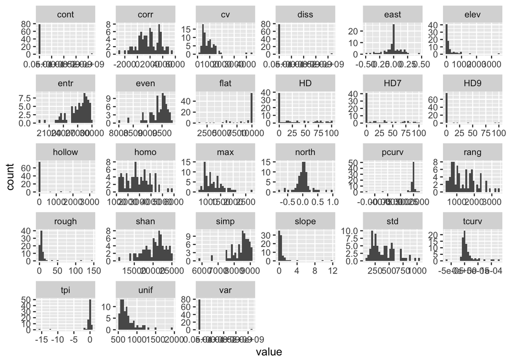

```r
earthenv %>%
  gather(key = "var", value = "value", 15:41) %>%
  ggplot(aes(value)) +
  geom_histogram() +
  facet_wrap(~var, scales = 'free')
```

`cont`, `diss`, and `var` have extreme outliers (xmax = 10e+09)

###### Replace extreme outliers with median

```r
earthenv <- earthenv %>%
  gather(key = "var", value = "value", 15:41) %>%
  group_by(var) %>%
  mutate(value = ifelse(value > 10^9, median(value, na.rm = TRUE), value)) %>%
  ungroup() %>%
  spread(key = "var", value = "value")
```

Visualize again above to check they are corrected.

###### Also check for missing data:

```r
earthenv %>%
  gather(key = "var", value = "value", 15:41) %>%
  mutate(missing = is.na(value)) %>%
  group_by(ID) %>%
  summarize(total = n(),
            missing = sum(missing)) %>%
  arrange(desc(missing))
```

```
## # A tibble: 81 x 3
##    ID    total missing
##    <chr> <int>   <int>
##  1 USDPW    27      11
##  2 USWPT    27      11
##  3 ATNeu    27       0
##  4 BRNpw    27       0
##  5 BWGum    27       0
##  6 BWNxr    27       0
##  7 CASCB    27       0
##  8 CASCC    27       0
##  9 CHCha    27       0
## 10 CHDav    27       0
## # … with 71 more rows
```

###### There are two sites (USDPW and USWPT) with missing values. Plot the sites:

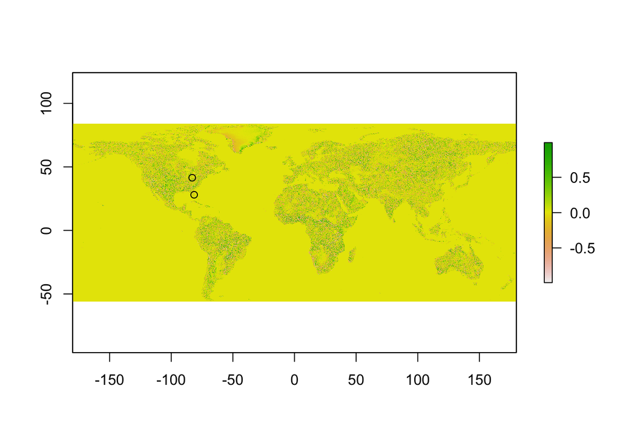

```r
plot(stack[[1]])
points(site.coords[sites$ID %in% c("USDPW", "USWPT"), ])
```

###### Fill with nearby site values.

USDPW from USLA1

USWPT from USOWC

```r
earthenv[earthenv$ID == "USDPW", c(is.na(earthenv[earthenv$ID == "USDPW", ])) ] <- earthenv[earthenv$ID == "USLA1", c(is.na(earthenv[earthenv$ID == "USDPW", ])) ]
earthenv[earthenv$ID == "USWPT", c(is.na(earthenv[earthenv$ID == "USWPT", ])) ] <- earthenv[earthenv$ID == "USOWC", c(is.na(earthenv[earthenv$ID == "USWPT", ])) ]
```

##### N and S Deposition

From Lamarque et al. 2013:

- accmip_nhx_acchist_2000.nc
- accmip_noy_acchist_2000.nc
- accmip_sox_acchist_2000.nc

```r
raster.names <- list.files(paste(loc, "grids/ns-deposition/", sep = ""), pattern = "nc$", full.names = FALSE)
stack <- stack(paste(loc, "grids/ns-deposition/", raster.names, sep = ""))
```

[output not shown]

[output not shown]

[output not shown]

[output not shown]

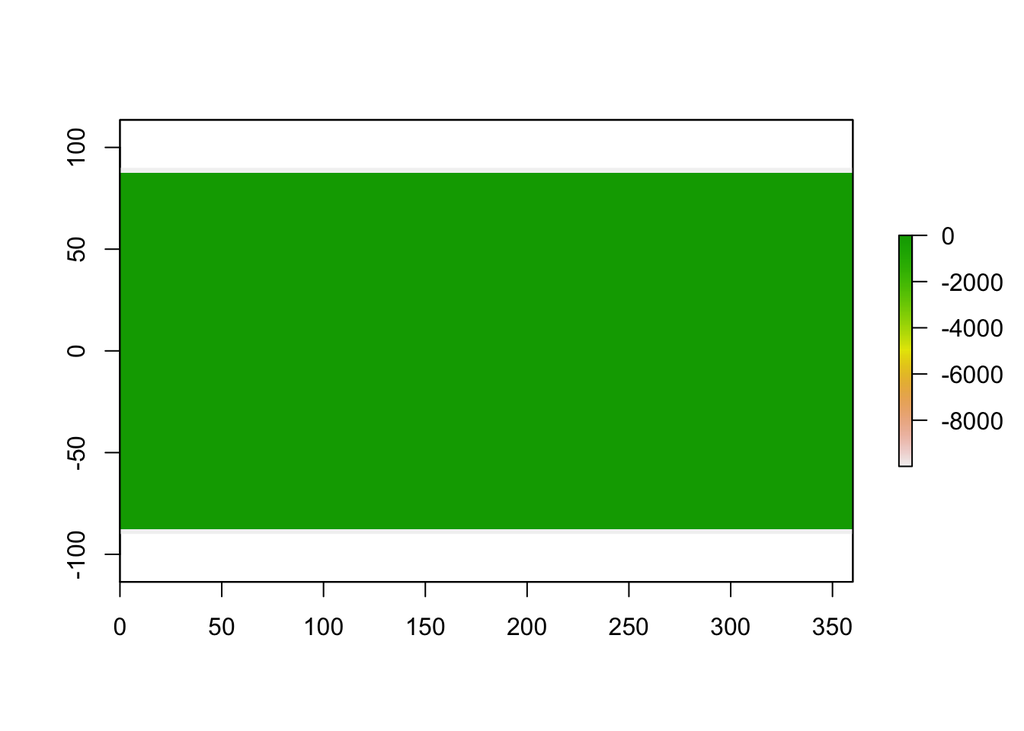

```r
plot(stack[[3]])
```

```r
ns_depo <- as_tibble(raster::extract(stack, site.coords))
ns_depo <- cbind(sites, ns_depo) %>%
  rename(nx_depo = Dry.deposition.NH3.NH4,
         ny_dep = Dry.deposition.NOy,
         s_dep = Dry.deposition.SO2.SO4)
head(ns_depo)
```

```
##      ID                 Site Name Data Policy  Country  Latitude  Longitude
## 1 ATNeu                  Neustift   CC-BY-4.0  Austria  47.11667   11.31750
## 2 BRNpw Northern Pantanal Wetland   CC-BY-4.0   Brazil -16.49800  -56.41200
## 3 BWGum                      Guma   CC-BY-4.0 Botswana -18.96472   22.37111
## 4 BWNxr                   Nxaraga   CC-BY-4.0 Botswana -19.54806   23.17917
## 5 CASCB          Scotty Creek Bog   CC-BY-4.0   Canada  61.30890 -121.29840
## 6 CASCC    Scotty Creek Landscape   CC-BY-4.0   Canada  61.30790 -121.29920
##   IGBP Site Classification  Upland Class                  DOI
## 1  GRA              Upland Alpine meadow 10.18140/FLX/1669365
## 2  WSA               Swamp          <NA> 10.18140/FLX/1669368
## 3  WET               Swamp          <NA> 10.18140/FLX/1669370
## 4  GRA               Swamp          <NA> 10.18140/FLX/1669518
## 5  WET                 Bog          <NA> 10.18140/FLX/1669613
## 6  ENF                 Bog          <NA> 10.18140/FLX/1669628
##                 DOI Reference                  Site Personnel
## 1      Wohlfahrt et al., 2020                 Georg Wohlfahrt
## 2      Vourlitis et al., 2020                George Vourlitis
## 3              Helfter, 2020a                  Carole Helfter
## 4              Helfter, 2020b                  Carole Helfter
## 5 Sonnentag and Helbig, 2020a Oliver Sonnentag, Manuel Helbig
## 6 Sonnentag and Helbig, 2020b Oliver Sonnentag, Manuel Helbig
##              Base File Host Upscaling      nx_depo       ny_dep        s_dep
## 1 EuroFlux Database Cluster        NA 8.835366e-12 9.246686e-12 7.589793e-12
## 2                 AmeriFlux         1           NA           NA           NA
## 3 EuroFlux Database Cluster         1 4.000257e-12 2.573803e-12 9.712278e-13
## 4 EuroFlux Database Cluster         1 2.755886e-12 2.421388e-12 1.024958e-12
## 5                 AmeriFlux         1           NA           NA           NA
## 6                 AmeriFlux         1           NA           NA           NA
```

##### Fractional Vegetation Cover (VCF)

##### Wetland Extent (WAD2M)

##### WorldClim 2.0